# README.md

Florencia Grattarola

2 July 2020

The following scripts were used to generate the analyses and figures of the Data Paper “Biodiversidata: A novel dataset for the vascular plant species diversity in Uruguay”, published in the Biodiversity Data Journal.

The dataset **Biodiversidata_Plants_1.0.0** provides primary biodiversity data on extant vascular plant (native and introduced) species recorded within the country area of Uruguay. This is [Biodiversidata](http://biodiversidata.org)’s second open-access set of data on the biodiversity of the country.

We will see the data’s:

1. Taxonomic coverage
2. Temporal coverage
3. Geographic coverage

To run this code you will need the following R packages:

```
library(extrafont)
library(lubridate)
library(gridExtra)
library(ggpubr)
library(sf)
library(tidyverse)
```

## First, let’s explore the data!

Let’s start by reading the data from the database. Once you have downloaded the dataset, the data will look like this (a tibble with **12,470** rows and **61** columns):

```r
Biodiversidata_Plants
```

```
## # A tibble: 12,470 x 61
##    license occurrenceID basisOfRecord recordedBy establishmentMe~
##    <chr>   <chr>        <chr>         <chr>      <chr>
##  1 https:~ Biodiversid~ HumanObserva~ Andrés Go~ introducida
##  2 https:~ Biodiversid~ HumanObserva~ Andrés Go~ nativa
##  3 https:~ Biodiversid~ HumanObserva~ Andrés Go~ nativa
##  4 https:~ Biodiversid~ HumanObserva~ Andrés Go~ nativa
##  5 https:~ Biodiversid~ HumanObserva~ Andrés Go~ nativa
##  6 https:~ Biodiversid~ HumanObserva~ Andrés Go~ nativa
##  7 https:~ Biodiversid~ HumanObserva~ Andrés Go~ nativa
##  8 https:~ Biodiversid~ HumanObserva~ Andrés Go~ nativa
##  9 https:~ Biodiversid~ HumanObserva~ Andrés Go~ nativa
## 10 https:~ Biodiversid~ HumanObserva~ Andrés Go~ nativa
## # ... with 12,460 more rows, and 56 more variables:
## #   previousIdentifications <chr>, eventDate <chr>, year <dbl>, month <dbl>,
## #   day <dbl>, higherGeography <chr>, continent <chr>, country <chr>,
## #   countryCode <chr>, stateProvince <chr>, locality <chr>,
## #   decimalLatitude <dbl>, decimalLongitude <dbl>, geodeticDatum <chr>,
## #   coordinateUncertaintyInMeters <dbl>, coordinatePrecision <dbl>,
## #   georeferencedBy <chr>, identifiedBy <chr>, taxonID <chr>,
## #   scientificName <chr>, nameAccordingTo <chr>, higherClassification <chr>,
## #   kingdom <chr>, phylum <chr>, class <chr>, order <chr>, family <chr>,
## #   species <chr>, genus <chr>, specificEpithet <chr>,
## #   infraspecificEpithet <chr>, taxonRank <chr>,
## #   scientificNameAuthorship <chr>, institutionCode <chr>,
## #   collectionCode <chr>, catalogNumber <chr>, recordNumber <chr>,
## #   associatedReferences <chr>, verbatimLocality <chr>,
## #   georeferenceRemarks <chr>, vernacularName <chr>, locationAccordingTo <chr>,
## #   georeferencedDate <date>, georeferenceSources <chr>,
## #   georeferenceVerificationStatus <chr>, organismRemarks <chr>,
## #   verbatimLatitude <chr>, verbatimLongitude <chr>,
## #   verbatimCoordinateSystem <chr>, locationRemarks <chr>,
## #   measurementType <chr>, measurementValue <chr>,
## #   measurementDeterminedBy <chr>, measurementRemarks <chr>, language <chr>,
## #   otherCatalogNumbers <chr>
```

### What’s the total amount of records and species in the database?

To get sumarised data out of our database, such as the total number of species or the total number of records with date of collection, we use the function `summarise` together with `n_distinct`. We can `group_by` any column we want, for example, by the taxonomic **class** of each record or by any specific **group**. To get the **Total** values, we can also summarise without grouping the data.

```r
Biodiversidata_Plants %>%
  mutate(group=ifelse(class=='Magnoliopsida'|class=='Liliopsida', 'Angiosperms',
                            ifelse(class=='Gnetopsida'|class=='Pinopsida', 'Gymnosperms',
                                   ifelse(class=='Polypodiopsida', 'Ferns',
                                          'Lycophytes')))) %>%
  group_by(group) %>% # use this or comment depending on the output you want
  summarise(N= n(), # total number of records
            S= n_distinct(species), # number of species
            wDate= sum(!(is.na(year))), # records that have a year of collection
            last30y = sum(year>1990, na.rm = T), # records that were collected in the last 30 years
            wCoordinates= sum(!(is.na(decimalLatitude))))  # records that have a decimal latitude
```

Here’s a table that summarises all the data, binding the information extracted for the groupped data and for the total data. To produce the table we are using `knitr::kable`.

| Group | Number of Occurrence Records | Number of Species | Records with Date (%) | Records from the last 30 years (%) | Records with Coordinates (%) |
| --- | --- | --- | --- | --- | --- |
| Lycophytes | 13 | 6 | 13 (100) | 11 (84.6) | 13 (100) |
| Ferns | 540 | 78 | 540 (100) | 508 (94.1) | 540 (100) |
| Gymnosperms | 48 | 5 | 41 (85.4) | 39 (81.2) | 48 (100) |
| Angiosperms | 11869 | 1559 | 10527 (88.7) | 9585 (80.8) | 11869 (100) |
| Total | 12470 | 1648 | 11121 (89.2) | 10143 (81.3) | 12470 (100) |

### General overview

To get other useful information to fill the metadata section, we will also summarise fields such as:

```r
knitr::kable(Biodiversidata_Plants %>%
  unite('species', genus, specificEpithet, na.rm = TRUE, sep = ' ', remove = FALSE) %>%
  mutate(places=str_c(decimalLatitude, decimalLongitude)) %>% # unique point locations
  summarise(recordsT= n(),
            speciesN= n_distinct(species),
            familyN= n_distinct(family),
            genusN= n_distinct(genus),
            placesN= n_distinct(places),
            StartDate=min(eventDate, na.rm = T),
            EndDate=max(eventDate, na.rm = T),
            North=max(decimalLatitude),
            South=min(decimalLatitude),
            East=max(decimalLongitude),
            West=min(decimalLongitude),
            departamentos=n_distinct(stateProvince)) %>%
  rename('Occurrence Records'=recordsT, 'Number of Species'=speciesN,
         'Families'=familyN, 'Genera'=genusN,
         'Localities (lat/lon)'=placesN, 'Start Date'=StartDate,
         'End Date'=EndDate, 'States (Departamentos)'=departamentos),  align = 'r')
```

| Occurrence Records | Number of Species | Families | Genera | Localities (lat/lon) | Start Date | End Date | North | South | East | West | States (Departamentos) |
| --- | --- | --- | --- | --- | --- | --- | --- | --- | --- | --- | --- |
| 12470 | 1648 | 160 | 760 | 4567 | 1877-02 | 2020-05-21 | -30.17587 | -34.9751 | -53.2636 | -58.43 | 19 |

## 1) Taxonomic coverage

### What’s the number of records/species/families per group?

| Group | Records | Species | Families |
| --- | --- | --- | --- |
| Lycophytes | 13 | 6 | 2 |
| Ferns | 540 | 78 | 15 |
| Gymnosperms | 48 | 5 | 4 |
| Angiosperms | 11869 | 1559 | 139 |

To simplify the plots we are going to keep only the families of Angiosperms and Ferns with more than 50 a 20 records respectively. We will use this variable `familiesToPlot` to filter families in the following plots:

```r
familiesToPlot <- Biodiversidata_Plants %>%
  group_by(class, family) %>% count() %>%
  mutate(classLevels=ifelse(class=='Magnoliopsida'|class=='Liliopsida', 'Angiosperms',
                            ifelse(class=='Gnetopsida'|class=='Pinopsida', 'Gymnosperms',
                                   ifelse(class=='Polypodiopsida', 'Ferns',
                                          'Lycophytes')))) %>%
  filter(classLevels!='Angiosperms' | classLevels=='Angiosperms'& n>=50) %>%
  filter(classLevels!='Ferns' | classLevels=='Ferns'& n>=20) %>% pull(family)
```

Now we plot the number of records by family, faceting the plots by group.

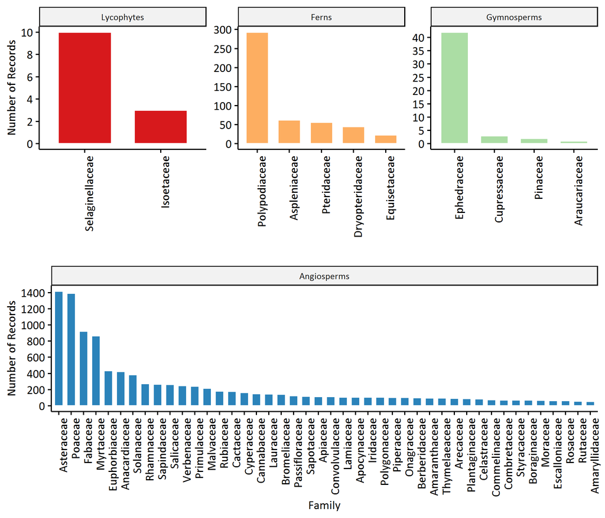

```r
grid.arrange(Biodiversidata_Plants %>%
  group_by(class, family) %>% count() %>%
  mutate(classLevels=ifelse(class=='Magnoliopsida'|class=='Liliopsida', 'Angiosperms',
                            ifelse(class=='Gnetopsida'|class=='Pinopsida', 'Gymnosperms',
                                   ifelse(class=='Polypodiopsida', 'Ferns',
                                          'Lycophytes')))) %>%
  filter(classLevels!='Angiosperms' & family %in% familiesToPlot) %>%
  mutate(classLevels=factor(classLevels, levels=c('Lycophytes',
                                                  'Ferns',
                                                  'Gymnosperms',
                                                  'Angiosperms'))) %>%
  ggbarplot(x = "family", y = "n",
            fill = "classLevels",
            color = "white",
            drop= T,
            palette = c("#D7191C", "#FDAE61", "#ABDDA4"),
            sort.val = "desc",
            x.text.angle = 90,
            legend = "none",
            ylab = 'Number of Records', xlab = '') +
  scale_y_continuous(breaks=scales::breaks_extended(8))+
  theme(text=element_text(family='Calibri', size = 10)) +
  facet_wrap(~classLevels, nrow=2, ncol=3, scales = "free", drop=TRUE),
  Biodiversidata_Plants %>%
    group_by(class, family) %>% count() %>%
    mutate(classLevels=ifelse(class=='Magnoliopsida'|class=='Liliopsida', 'Angiosperms',
                              ifelse(class=='Gnetopsida'|class=='Pinopsida', 'Gymnosperms',
                                     ifelse(class=='Polypodiopsida', 'Ferns',
                                            'Lycophytes')))) %>%
    filter(classLevels=='Angiosperms' & family %in% familiesToPlot) %>%
    mutate(classLevels=factor(classLevels, levels=c('Lycophytes',
                                                    'Ferns',
                                                    'Gymnosperms',
                                                    'Angiosperms'))) %>%
    ggbarplot(x = "family", y = "n",
              fill = "classLevels",
              color = "white",
              drop= T,
              palette = "#2B83BA",
              sort.val = "desc",
              x.text.angle = 90,
              legend = "none",
              ylab = 'Number of Records', xlab = 'Family') +
    scale_y_continuous(breaks=scales::breaks_extended(8))+
    theme(text=element_text(family='Calibri', size = 10)) +
    facet_wrap(~classLevels, nrow=2, ncol=3, scales = "free", drop=TRUE))
```

## 2) Temporal coverage

The occurrence records included in Biodiversidata’s plants database cover samples reported in Uruguay during the period of **1877–2020**. How are these records distributed over time within the groups?

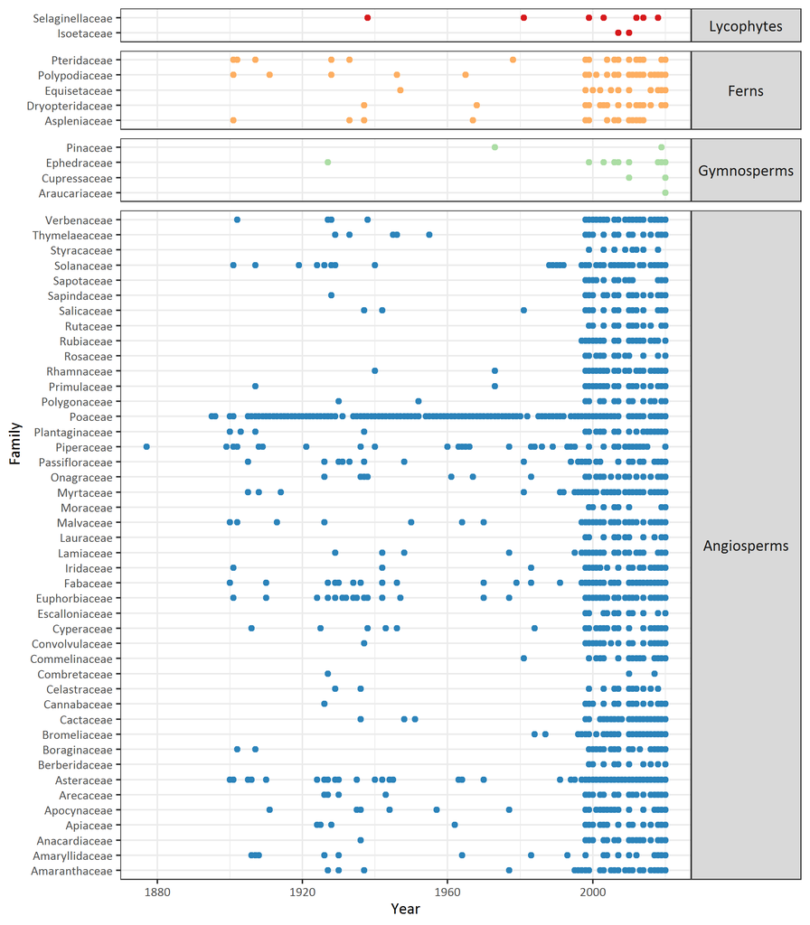

```r
Biodiversidata_Plants %>%
  mutate(classLevels=ifelse(class=='Magnoliopsida'|class=='Liliopsida', 'Angiosperms',
                            ifelse(class=='Gnetopsida'|class=='Pinopsida', 'Gymnosperms',
                                   ifelse(class=='Polypodiopsida', 'Ferns',
                                          'Lycophytes')))) %>%
  mutate(classLevels=factor(classLevels, levels=c('Lycophytes',
                                                  'Ferns',
                                                  'Gymnosperms',
                                                  'Angiosperms'))) %>%
  filter(family %in% familiesToPlot) %>%
  ggplot(aes(x=year, y=family, color=classLevels)) +
  geom_point(show.legend = FALSE) +
  scale_colour_brewer(palette ='Spectral')+
  facet_grid(classLevels~., scales = "free", space= 'free_y', switch='x' ,drop=TRUE) +
  theme_bw() +
  theme(text=element_text(family='Calibri', size=10)) +
  theme(strip.text.y = element_text(size=10, angle=0)) +
  labs(x='Year', y='Family', color = '')
```

## 3) Geographic coverage

To finish let’s map the records.

First, we need to download Uruguay’s shapefile data with the level 1 for administrative boundaries. We can use the package `geouy` to download this data or [GADM](https://gadm.org/).

```
Departamentos <- load_geouy('Departamentos') # We will use this one
Uruguay <- getData("GADM", country="UY", level=1)
```

Also, we will need a grid of 25x25km unit-size to plot sampling effort (you can create one using the `st_make_grid` function).

```r
Grid_UY25 <- st_read('Grid_UY25.shp')
```

Finally, we are going to convert the plants data into an `sf` object.

```r
Biodiversidata_Plants_GIS <- Biodiversidata_Plants %>%
  as.data.frame %>%
  sf::st_as_sf(coords = c("decimalLongitude", "decimalLatitude")) %>%
  st_set_crs(4326) %>% st_transform(32721) # this CRS and transformation is specifically for Uruguay
```

#### Sampling effort analysis

To measure sampling effort we perform a spatial filter using `st_join`, with the gridded map as a base to count the occurence records that are *contained* within each grid-cell.

```r
Grid_UY25_Plants <- st_join(x=Grid_UY25,
                                  y=(Biodiversidata_Plants_GIS %>%
                                       select(species)), # to simplify we just keep the species field
                                  left=TRUE, join = st_contains) %>%
  group_by(Id) %>%
  summarise(samplingEffort=ifelse(n_distinct(species, na.rm = TRUE)==0, 0, n())) # records per grid
```

Now we map the occurrence records and the distribution of the sampling effort.

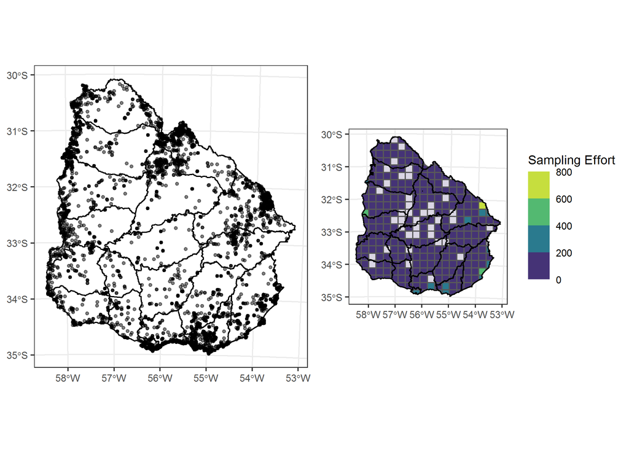

```r
occurrenceRecords <- ggplot() +
  geom_sf(data = Departamentos, color='black', fill='white') +
  geom_sf(data = Biodiversidata_Plants_GIS, size=1, alpha=0.5) +
  theme_bw() +
  theme(text=element_text(size=10))

samplingEffort <- ggplot() +
  geom_sf(data = Grid_UY25_Plants, aes(fill=samplingEffort)) +
  scale_fill_binned(n.breaks=5, type = "viridis", show.limits = TRUE) +
  geom_sf(data = Grid_UY25_Plants %>% filter(samplingEffort==0), aes(fill=N), fill='white', alpha=0.8)+
  geom_sf(data = Departamentos, color='black', fill=NA) +
  labs(fill = 'Sampling Effort') +
  theme_bw() +
  theme(text=element_text(size=10))

gridExtra::grid.arrange(occurrenceRecords, samplingEffort, nrow=1)
```

- For the Data Paper we used [Inkscape](https://inkscape.org/es/) and **ArcGis 10.6** to improve this maps.